# 20231108_SonjaB_duloxlsostev_AA

Stephan Kamrad, Rui Guan, Kiran R. Patil

2023-11-22

## Introduction

In this project, we analyzed 133 samples in total, including 113 samples, with 15 external standard samples and 5 blank samples for quality control. In total, the results of 32 compounds are presented in this report. Below we show the first few sample and compound IDs.

| Sample |
| --- |
| Blasche-S3_P3-A1 |
| Blasche-S3_P3-A10 |
| Blasche-S3_P3-A11 |
| Blasche-S3_P3-A12 |
| Blasche-S3_P3-A2 |
| Blasche-S3_P3-A3 |

| Compound |
| --- |
| Nicotinic Acid |
| Kynurenine |
| Glutamine |
| Tyrosine |
| Lysine |
| Cadaverine |

## Results

### 1. Quality control of LC-MS data

To monitor the changes in chromatographic properties, we examined the retention time of samples (including the blank and standard samples used as control). For example, **Figure 1** shows the retention time of compound **Kynurenine**, no large variation was observed (gray solid line indicates the average of retention time over measurements and two dashed lines indicate +5% and -5% deviation). See the full list of compounds in

Download s1_rt.pdf

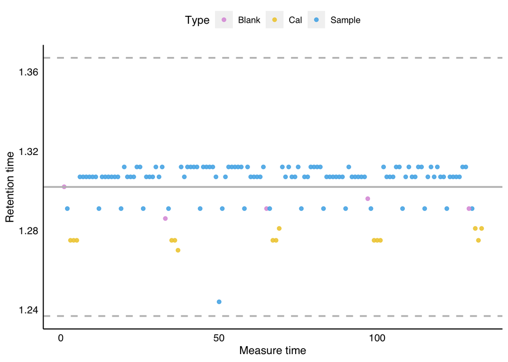

### 2. Limits of detection (LOD)

By comparing the calculated concentration to the real concentration of standard compounds, as well as taking into account the fitness of regression, we determined the upper and lower limits of detection (**LOD**) for each compound. Below we show the distribution of samples (in blue) compared to standards (gold) with different concentrations and blank samples (in purple). The salmon dash line indicates the lower LOD of corresponding compounds, indicated by R-squared value changes in regression. Shapes of data points corresponding to the signal-to-noise ratio, above (triangle) or below (circle) the threshold (S/N = 10). Take compound **Kynurenine** as an example again (**Figure 2**) as shown below and the figure of all compounds could be found in

Download s1_std_curve.pdf

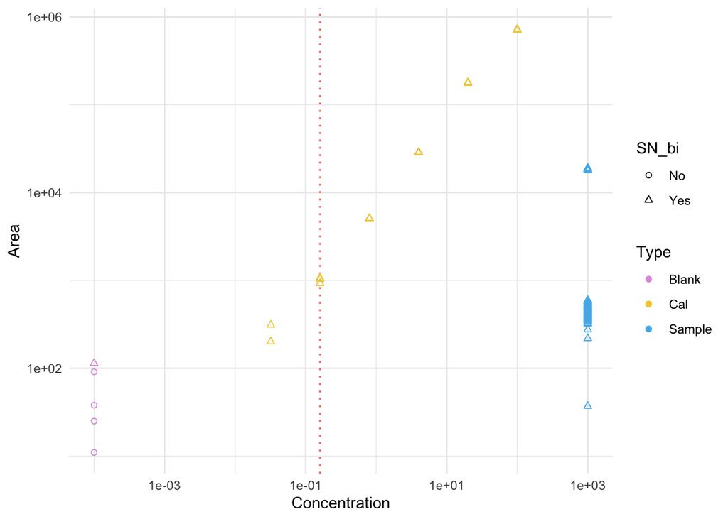

Below we also show the information on the first few compounds:

| Name | Compound | Within_detection | Calculated_Concentration |
| --- | --- | --- | --- |
| Blasche-S3_P3-A1 | Nicotinic Acid | Lower | 0.0727 |
| Blasche-S3_P3-A1 | Kynurenine | Lower | 0.0664 |
| Blasche-S3_P3-A1 | Glutamine | Yes | 0.2307 |
| Blasche-S3_P3-A1 | Tyrosine | Yes | 1.3203 |
| Blasche-S3_P3-A1 | Lysine | Yes | 81.4866 |
| Blasche-S3_P3-A1 | Cadaverine | Yes | 0.8436 |

### 3. Data normalization

Probabilistic quotient normalization (**pqn**) was implemented (Dieterle F 2006) to normalize the concentration of samples. A random sample was chosen as the “reference” sample. The ratios between all other samples and the reference sample for all compounds were computed and the median value was extracted as the normalization factor the sample. New columns named “**Factor_pqn**” and “**Calculated_concentration_reNorm_pqn**” were added, indicating the computed normalization factor for each sample and the concentration of compounds after the **pqn** normalization, respectively.

#### Attention:

Please think carefully if **pqn** normalization is suitable for your project and decide if the original or normalized calculated concentration should be used for further analysis (Table S2).

| Name | Compound | Within_detection | Factor_pqn | Calculated_concentration_reNorm_pqn |
| --- | --- | --- | --- | --- |
| Blasche-S3_P3-A1 | Nicotinic Acid | Lower | 1.053333 | 0.3450949 |
| Blasche-S3_P3-A1 | Kynurenine | Lower | 1.053333 | 0.3151898 |
| Blasche-S3_P3-A1 | Glutamine | Yes | 1.053333 | 1.0950947 |
| Blasche-S3_P3-A1 | Tyrosine | Yes | 1.053333 | 6.2672456 |
| Blasche-S3_P3-A1 | Lysine | Yes | 1.053333 | 386.8034072 |
| Blasche-S3_P3-A1 | Cadaverine | Yes | 1.053333 | 4.0044296 |

### 4. QC samples for quality control

We also examined the peak areas over time for QC samples. Some compounds fluctuated more than others regarding areas, and when the difference between specific measurement and average area is larger than 25% of the average area, a warning is generated (and also indicated as “Yes” for “Warning” in figure below). The golden solid line indicates the average area of QC samples over time and dashed lines indicate the +25% and -25% deviation.

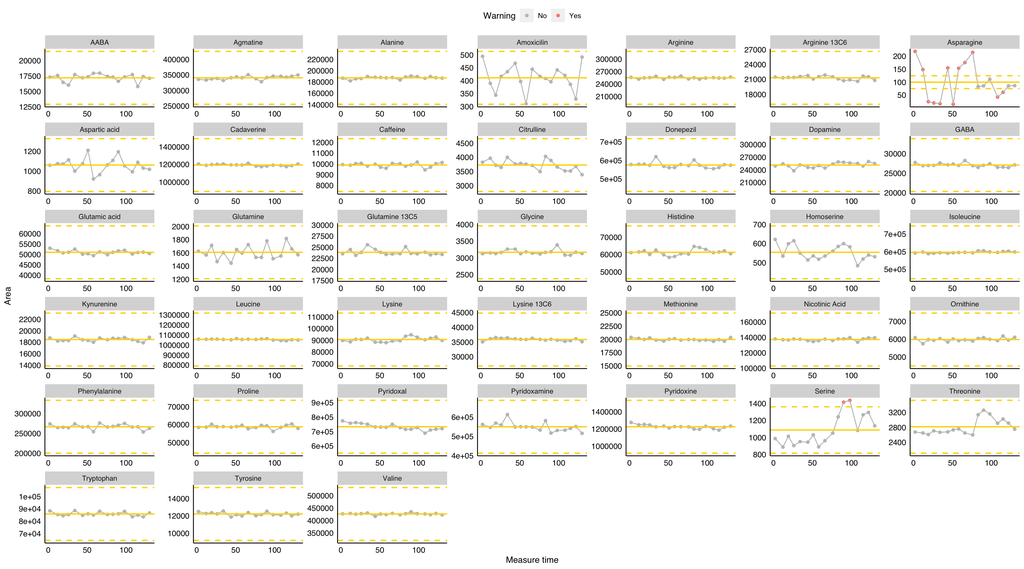

Figure could be downloaded from here too:

Download s3_area_over_time_facet.pdf

Specific compounds and measurement that triggered the warning:

| Name | Compound | Acq..Date.Time | Area | Mean | SD | Deviation_percentage |
| --- | --- | --- | --- | --- | --- | --- |
| QC_12 | Serine | 11/7/23 22:03 | 1412 | 1086.41176 | 179.25124 | 29.96914 |
| QC_13 | Serine | 11/7/23 22:35 | 1434 | 1086.41176 | 179.25124 | 31.99415 |
| QC_1 | Asparagine | 11/7/23 16:10 | 218 | 99.17647 | 67.73407 | 119.81020 |
| QC_2 | Asparagine | 11/7/23 16:49 | 148 | 99.17647 | 67.73407 | 49.22894 |
| QC_3 | Asparagine | 11/7/23 17:17 | 24 | 99.17647 | 67.73407 | 75.80071 |
| QC_4 | Asparagine | 11/7/23 17:45 | 19 | 99.17647 | 67.73407 | 80.84223 |
| QC_5 | Asparagine | 11/7/23 18:17 | 16 | 99.17647 | 67.73407 | 83.86714 |
| QC_6 | Asparagine | 11/7/23 19:01 | 154 | 99.17647 | 67.73407 | 55.27877 |
| QC_7 | Asparagine | 11/7/23 19:28 | 14 | 99.17647 | 67.73407 | 85.88375 |
| QC_8 | Asparagine | 11/7/23 19:56 | 153 | 99.17647 | 67.73407 | 54.27046 |
| QC_9 | Asparagine | 11/7/23 20:28 | 175 | 99.17647 | 67.73407 | 76.45314 |
| QC_10 | Asparagine | 11/7/23 21:08 | 214 | 99.17647 | 67.73407 | 115.77699 |
| QC_14 | Asparagine | 11/7/23 23:19 | 42 | 99.17647 | 67.73407 | 57.65125 |
| QC_15 | Asparagine | 11/7/23 23:47 | 60 | 99.17647 | 67.73407 | 39.50178 |

### 5. Overview of the detected compounds

Below we show the number of samples that each compound were detected in:

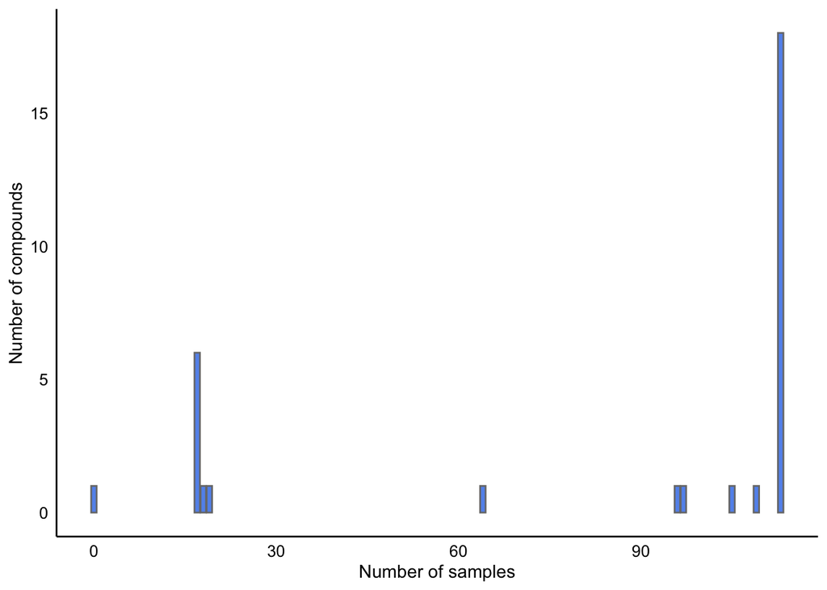

And the number of compounds that each sample was detected to contain:

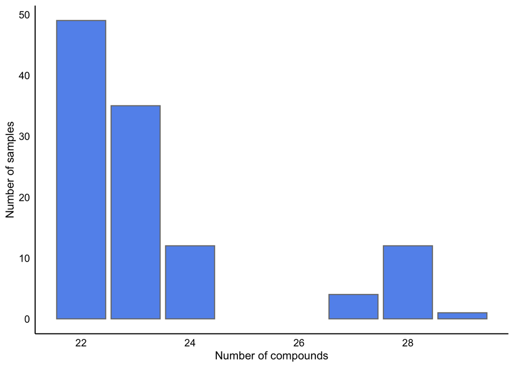

## Conclusion

In conclusion, we were able to detect most of the compounds in most of the samples. Below we listed the compounds that were reliably detected, didn’t work well, and were excluded for processing.

##### 1. Reliably detected (at least in intracellular samples) compounds with individual notes:

| Compound | Annotation | Comments |
| --- | --- | --- |
| Caffeine | WorkedWell |  |
| Donepezil | WorkedWell |  |
| Leucine | WorkedWell | Peak overlapping with Isoleucine |
| Phenylalanine | WorkedWell |  |
| Tryptophan | WorkedWell |  |
| Isoleucine | WorkedWell | Peak overlapping with Leucine |
| Methionine | WorkedWell |  |
| Valine | WorkedWell |  |
| Tyrosine | WorkedWell |  |
| AABA | WorkedWell |  |
| Amoxicilin | WorkedWell | Probably the best choice of internal standard |
| Alanine | WorkedWell | Slightly above calibrated range, but not saturated |
| Threonine | WorkedWell |  |
| Glycine | WorkedWell |  |
| Glutamine 13C5 | WorkedWell |  |
| Glutamine | WorkedWell |  |
| Glutamic acid | WorkedWell |  |
| Serine | WorkedWell |  |
| Asparagine | WorkedWell |  |
| Citrulline | WorkedWell |  |
| Agmatine | WorkedWell |  |
| GABA | WorkedWell |  |
| Cadaverine | WorkedWell |  |
| Aspartic acid | WorkedWell |  |
| Histidine | WorkedWell |  |
| Arginine 13C6 | WorkedWell |  |
| Lysine 13C6 | WorkedWell |  |
| Proline | WorkedWell |  |
| Ornithine | WorkedWell |  |

##### 2. Compounds that didn’t work perfectly, need further discussion:

| Compound | Annotation | Comments |
| --- | --- | --- |
| Nicotinic Acid | Maybe | Quite low |
| Pyridoxal | Maybe | Quite low |
| Pyridoxine | Maybe | Quite low |
| Dopamine | Maybe | Quite low |
| Kynurenine | Maybe | Quite low |
| Homoserine | Maybe | A bit noisy |
| Arginine | Maybe | Above calibrated range, slightly saturated |

##### 3. Compounds that were excluded:

| Compound | Annotation | Comments |
| --- | --- | --- |
| Serotonin | Exclude | Not detected in Samples, interference |
| Thiamine | Exclude | Not detected in Samples |
| Homocysteine | Exclude | Not detected in Samples |
| 3-Hydroxykynurenine | Exclude | Not detected in Samples |
| Taurine | Exclude | Not detected in Samples |
| Pyridoxal-5-Phosphate | Exclude | Not detected in Samples |
| Folic Acid | Exclude | Not detected in Samples |
| Folinic Acid | Exclude | Not detected in Samples |
| DOPA | Exclude | Not detected in Samples |
| Methylcobalamine | Exclude | Not detected in Samples |
| Cyanocobalamine | Exclude |  |
| Anserine | Exclude | Not detected in Samples |
| Carnosine | Exclude | Not detected in Samples |

## Material and methods

Measured on: 7.11.2023  
Internal method designation: 20231107_AA_3min  
Methods are modified from previous publication (Mülleder M 2016).

### Sample preparation

Supenatant samples were collected by Sonja. 80ul of a 10x dilution in water was prepared and 120ul of extraction buffer (1:1 MeOH:ACN + 20uM of each donepizil, caffeine, amoxicillin, ibuprofen) was added, followed by brief mixing and incubation at 4C for 30minutes. The extract was cleared by centrifugation (4C, 3200g, 5min) and the supernatant was transferred to a fresh PCR plate for analysis. Standard series was prepared in water. 0.25ul of internal standard dissolved in water containing labelled compounds was coinjected with each sample. Contains:

Sodium pyruvate 13C3 - 200uM  
Succinic acid 13C4 - 100uM  
Arginine 13C6 - 50uM  
Glutamine 13C5 - 50uM  
Citric acid 13C6 - 100uM  
Lysine 13C6 - 50uM

### LC-MS measurement

Mass spectrometer: Agilent triple quadrupole (QQQ) 6470 with JetStream ion source (AJS-ESI)  
UPLC instrument: Agilent 1290 Infinity II  
Acquisition scheme: dynamic (schedueled) MRM  
Chromatography: Hydrophilic interaction liquid chromatography (HILIC)  
Analytical Column: Waters Acquity BEH Amide 1.7 µm, 2.1 mm X 100 mm  
Column temperature: 35°C  
Needle wash: Water + 0.1% formic acid  
Injection Volume: 0.25µl  
Buffer A: 50% acetonitrile, 10 mM ammonium formate, 0.176% formic acid  
Buffer B: 95:5:5 acetonitrile:methanol:water, 10 mM ammonium formate, 0.176% formic acid  
Flow rate: 0.9ml/min  
Gradient: 0min:85%B, 0.7min:85%B, 2.55min:5%B, 2.9min:5%B, 2.91min:85%B, 3.5min:stoptime  
Source parameters: Gas temp:325°C, Gas flow:10 l/min, Nebulizer:40psi, Sheath gas temp:350°C, Sheath gas flow:11 l/min, Capillary (positive):3500V, Capillary (negative):3500V, Nozzle voltage (positive):1000V, Nozzle voltage (negative):100V  
Cycle time: 320ms

### LC-MS data analysis

Acquisition software: MassHunter Workstation LC/MS Data Acquisition v10.1  
Analysis software: MassHunter Workstation Quantitative Analysis for QQQ v10.1  
We used customized R scripts (in ./scripts/ folder) for the pre-processing and visualization of data.

## Supplementary Data

All the tables here could be downloaded through the following links or check them in the folder “./data”. Below we show the first few rows of each supplementary table:

### Table S1 The concentraion of standards.

Download s0_reformat_std_concentration.txt

| Compound | Concentration_in_stock_uM | Level | Concentration |
| --- | --- | --- | --- |
| Donepezil | NA | 8 | 100.000 |
| Donepezil | NA | 7 | 20.000 |
| Donepezil | NA | 6 | 4.000 |
| Donepezil | NA | 5 | 0.800 |
| Donepezil | NA | 4 | 0.160 |
| Donepezil | NA | 3 | 0.032 |

### Table S2 The concentration of samples.

Download s2_reformat_data_with_LOD_reNorm.txt

| Name | Compound | Data.File | Acq..Date.Time | Pos. | Type | Vol. | Level | FWHM | Area | RT | SN_ratio | Calculated_Concentration | Time | Concentration_volumn_adjust | LOD | Area_mean | Max_Area | Within_detection | Factor | Calculated_concentration_reNorm | Factor_pqn | Calculated_concentration_reNorm_pqn |
| --- | --- | --- | --- | --- | --- | --- | --- | --- | --- | --- | --- | --- | --- | --- | --- | --- | --- | --- | --- | --- | --- | --- |
| Blasche-S3_P3-A1 | Nicotinic Acid | Blasche-S3_P3-A1.d | 11/7/23 23:31 | P3-A1 | Sample | 0.2 | 0 | 0.041 | 4539 | 0.419 | 162.53 | 0.0727 | 111 | 0.3635 | 0.160 | 9843.0000 | 1128558.0 | Lower | 0.9898477 | 0.3672282 | 1.053333 | 0.3450949 |
| Blasche-S3_P3-A1 | Kynurenine | Blasche-S3_P3-A1.d | 11/7/23 23:31 | P3-A1 | Sample | 0.2 | 0 | 0.048 | 522 | 1.307 | 207.63 | 0.0664 | 111 | 0.3320 | 0.160 | 1008.3333 | 716755.3 | Lower | 0.9898477 | 0.3354051 | 1.053333 | 0.3151898 |
| Blasche-S3_P3-A1 | Glutamine | Blasche-S3_P3-A1.d | 11/7/23 23:31 | P3-A1 | Sample | 0.2 | 0 | 0.030 | 164 | 2.020 | 11.25 | 0.2307 | 111 | 1.1535 | 0.160 | 152.6667 | 116342.3 | Yes | 0.9898477 | 1.1653308 | 1.053333 | 1.0950947 |
| Blasche-S3_P3-A1 | Tyrosine | Blasche-S3_P3-A1.d | 11/7/23 23:31 | P3-A1 | Sample | 0.2 | 0 | 0.042 | 4617 | 1.597 | 8.00 | 1.3203 | 111 | 6.6015 | 0.064 | 258.0000 | 151604.0 | Yes | 0.9898477 | 6.6692080 | 1.053333 | 6.2672456 |
| Blasche-S3_P3-A1 | Lysine | Blasche-S3_P3-A1.d | 11/7/23 23:31 | P3-A1 | Sample | 0.2 | 0 | 0.036 | 173727 | 2.355 | 4325.68 | 81.4866 | 111 | 407.4330 | 0.160 | 1370.0000 | 198000.0 | Yes | 0.9898477 | 411.6118198 | 1.053333 | 386.8034072 |
| Blasche-S3_P3-A1 | Cadaverine | Blasche-S3_P3-A1.d | 11/7/23 23:31 | P3-A1 | Sample | 0.2 | 0 | 0.039 | 64339 | 2.148 | 207.26 | 0.8436 | 111 | 4.2180 | 0.160 | 17316.0000 | 1409136.0 | Yes | 0.9898477 | 4.2612617 | 1.053333 | 4.0044296 |

## Acknowledgement

We thank Michael Mülleder, High Throughput Mass Spectrometry Facility, Charité Universitätsmedizin Berlin for developing the method applied in this study.

## References

Dieterle F, Schlotterbeck G, Ross A. 2006. “Probabilistic Quotient Normalization as Robust Method to Account for Dilution of Complex Biological Mixtures.” *Anal Chem*. https://doi.org/10.1021/ac051632c.

Mülleder M, Alam MT, Calvani E. 2016. “Functional Metabolomics Describes the Yeast Biosynthetic Regulome.” *Cell*. https://doi.org/doi:10.1016/j.cell.2016.09.007.